# EDLD629 Final

Janette Avelar & Tony Daza

2023-06-08

# Descriptives

## Updated summary of locale by year

*Note:* Missing locale value indicates locale held a missing value.

```r
loc_desc <- main %>%
  mutate(rate = rep(1, nrow(.))) %>%
  group_by(year, locale) %>%
  summarize(N = sum(rate))
datatable(loc_desc)
```

|  | year | locale | N |
| --- | --- | --- | --- |
| 1 | 2019 | Rural | 41 |
| 2 | 2019 | Urban | 93 |
| 3 | 2019 | Suburban | 38 |
| 4 | 2019 |  | 1 |
| 5 | 2021 | Rural | 55 |
| 6 | 2021 | Urban | 135 |
| 7 | 2021 | Suburban | 39 |
| 8 | 2021 |  | 3 |
| 9 | 2022 | Rural | 33 |
| 10 | 2022 | Urban | 98 |

[output cut: 6 more lines]

## Updated boxplots for FRPL & BIPOC percentages

```r
frpl_viz <- ggplot(main, aes(year, frpl_percent, group = year)) +
  geom_boxplot() +
  theme_minimal()
# save(frpl_viz, file = "frpl_viz-updated.png")


bipoc_viz <- ggplot(main, aes(year, bipoc_percent, group = year)) +
  geom_boxplot() +
  theme_minimal()
# save(bipoc_viz, file = "bipoc_viz-updated.png")
```

## States represented

```r
state_rep <- main %>%
  mutate(rate = rep(1, nrow(.))) %>%
  group_by(school_state) %>%
  dplyr::summarize(n = sum(rate))
datatable(state_rep)
```

|  | school_state | n |
| --- | --- | --- |
| 1 |  | 5 |
| 2 | Alabama | 8 |
| 3 | Alaska | 1 |
| 4 | Arizona | 22 |
| 5 | Arkansas | 24 |
| 6 | California | 66 |
| 7 | Colorado | 67 |
| 8 | Connecticut | 15 |
| 9 | Delaware | 1 |
| 10 | District of Columbia | 32 |

[output cut: 41 more lines]

```r
#missing: Montana, Nebraska, Oregon, West Virginia
```

## Average implementation across years by locale

```r
desc_imp <- main %>%
  #creating a composite practice score for each school
  group_by(year, school_id) %>%
  mutate(comp_prac = sum(prac_culture + prac_sel_assess + prac_community + prac_marginalized + prac_mental + prac_restorative + prac_sel_curriculum + prac_sel_integrated + prac_resources, na.rm = TRUE)) %>%
  ungroup() %>%
  #create an average implementation score for each year
  group_by(year, locale) %>%
  filter(!is.na(locale)) %>%
  filter(!locale == "") %>%
  summarize(avg_prac = mean(comp_prac))
```

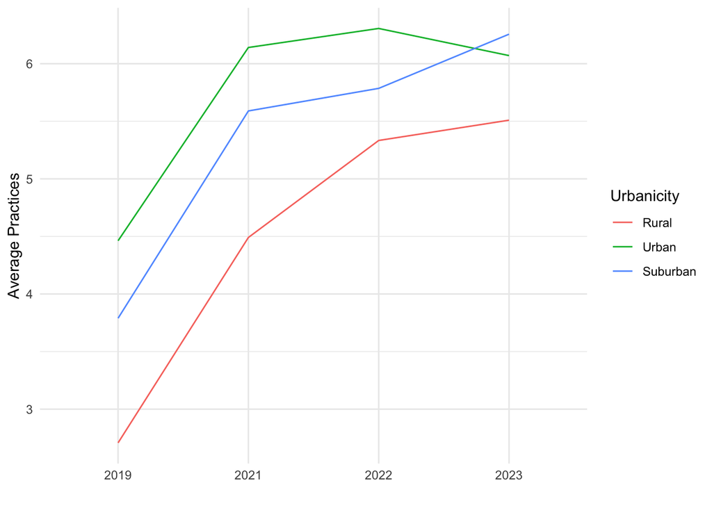

```r
#build plot
ggplot(desc_imp, aes(year, avg_prac,group = locale)) +
  geom_line(aes(color = locale))+
  theme_minimal() +
  labs(color = "Urbanicity",
       y = "Average Practices",
       x = "") +
  scale_y_continuous(n.breaks = 4)
```

Should recreate the plots above with regional data

Adding in total practices per year.

```r
main$prac_tot <- rowSums(main[c(5,6,7,8,9,10,11,12,13)], na.rm=TRUE)
# fixed dataset should make this redundant
# main <- main %>% mutate_at(c('locale'), ~na_if(.,''))

main$locale <- as.factor(main$locale)
```

Checking if my method works as well.

Adding in regional data

```r
library(datasets)


# Region
######################################
region <- as.data.frame(state.region)
region <- region %>% dplyr::mutate(State_ID = row_number())

# State name
######################################
states <- as.data.frame(state.name)
states <- states %>% dplyr::mutate(State_ID = row_number())

# Sub region
######################################
subregion <- as.data.frame(state.division)
subregion <- subregion %>% dplyr::mutate(State_ID = row_number())

# I realized that this data set doesn't have the District of Columbia
# It leads to some NA values
# I will sort them out later and for now just filter them out

# State abbreviation
######################################
abbr <- as.data.frame(state.abb)
abbr <- abbr %>% dplyr::mutate(State_ID = row_number())

# Joining all of the data
######################################
regions <- dplyr::full_join(states, subregion, by = "State_ID")
regions <- dplyr::full_join(regions, abbr, by = "State_ID")
regions <- dplyr::full_join(regions, region, by = "State_ID")

# Correcting a few issues
######################################
regions$state.division[[8]] <- "Middle Atlantic"
regions$state.region[[8]] <- "Northeast"
# For some reason Delaware was listed as the South and that seemed wrong.
regions$state.division[[32]] <- "New England"


# New row for DC
DC <- data.frame(state.name = "District of Columbia",
                 State_ID = 51,
                 state.division = "Middle Atlantic",
                 state.region = "Northeast",
                 state.abb = "DC")

# Adding in DC
regions <- rbind(regions, DC)
```

Adding in Political data

```r
pres_16 <- pres_16 %>% dplyr::rename(state.abb = STATE)
pres_16 <- dplyr::full_join(pres_16, regions, by = "state.abb")
pres_16 <- pres_16 %>% select(-c("State_ID", "state.abb", "All Other Parties"))
pres_16 <- pres_16 %>% dplyr::rename(school_state = state.name)
pres_16 <- pres_16 %>% dplyr::rename(school_region = state.region)
pres_16 <- pres_16 %>% dplyr::rename(school_subregion = state.division)

pres_16 <- pres_16 %>% mutate(pct_dem = round(((`Democrat Popular`/`Total Vote`)*100),2))



# Determine quantile thresholds for splitting categories
quantiles <- quantile(pres_16$pct_dem, probs = c(0, 1/3, 2/3, 1))

# Creating a new variable indicating the political affiliation based on percent voting democrat
pres_16 <- pres_16 %>%
  mutate(Political_Affiliation = case_when(
    pct_dem >= quantiles[3] ~ "Democrat",
    pct_dem >= quantiles[2] ~ "Neutral",
    TRUE ~ "Conservative"
  ))


# But does that show the same thing as electoral college?
## The answer is not quite

pres_16 <- pres_16 %>%
  mutate(`Republican Electoral` = replace(`Republican Electoral`, is.na(`Republican Electoral`), 0),
         `Democrat Electoral` = replace(`Democrat Electoral`, is.na(`Democrat Electoral`), 0))
# Hawaii splits electoral votes
pres_16$`Democrat Electoral`[[12]] <- 3
# Washington splits electoral votes
pres_16$`Democrat Electoral`[[48]] <- 8
# Texas splits electoral votes
pres_16$`Republican Electoral`[[44]] <- 36

pres_16 <- pres_16 %>%
  dplyr::mutate(`Republican Electoral` = as.numeric(`Republican Electoral`),
        `Democrat Electoral` =  as.numeric(`Democrat Electoral`))

# Now we can add the electoral votes
# Will need to fix Hawaii, Washington, and Texas
pres_16 <- pres_16 %>%
  group_by(school_state) %>%
  dplyr::mutate(Electoral_Total = `Republican Electoral` + `Democrat Electoral`)

# Hawaii has 4 electoral votes
pres_16$Electoral_Total[[12]] <- 4
# Washington has 12 electoral votes
pres_16$Electoral_Total[[48]] <- 12
# Texas has 38 electoral votes
pres_16$Electoral_Total[[44]] <- 38

# Now we will determine if the state's electoral votes went primarily to Republicans or democrats
pres_16 <- pres_16 %>% mutate(electoral_pct_dem = round(((`Democrat Electoral`/Electoral_Total)*100),2))

# Now a new category of state party by electoral college.
pres_16 <- pres_16 %>% mutate(Political_Aff_2 = case_when(
    electoral_pct_dem >= 50 ~ "Democrat",
    TRUE ~ "Conservative"
  ))

state_party <- pres_16 %>% select(c("school_state", "Political_Affiliation", "Political_Aff_2"))
```

Combining data: region, political, and main

```r
library(forcats)

main$school_state[[54]] <- "New York"
main$school_state[[136]] <- "California"
main$school_state[[373]] <- "South Carolina"
main$school_state[[377]] <- "Washington"


regions <- regions %>% select(-"State_ID")
regions <- regions %>% dplyr::rename(school_state = state.name)
regions <- regions %>% dplyr::rename(school_region = state.region)
regions <- regions %>% dplyr::rename(school_subregion = state.division)


full_region <- left_join(main, regions, by = "school_state")

full_region <- left_join(full_region, state_party, by = "school_state")

full_region$school_state[[667]] <- "Florida"
full_region$school_state[[632]] <- "District of Columbia"


full_region$locale <- fct_collapse(full_region$locale, "Suburban" = c("Suburban", "Suburban"))
```

# Descriptive Data

## Region, Urbanicity, Political Plots

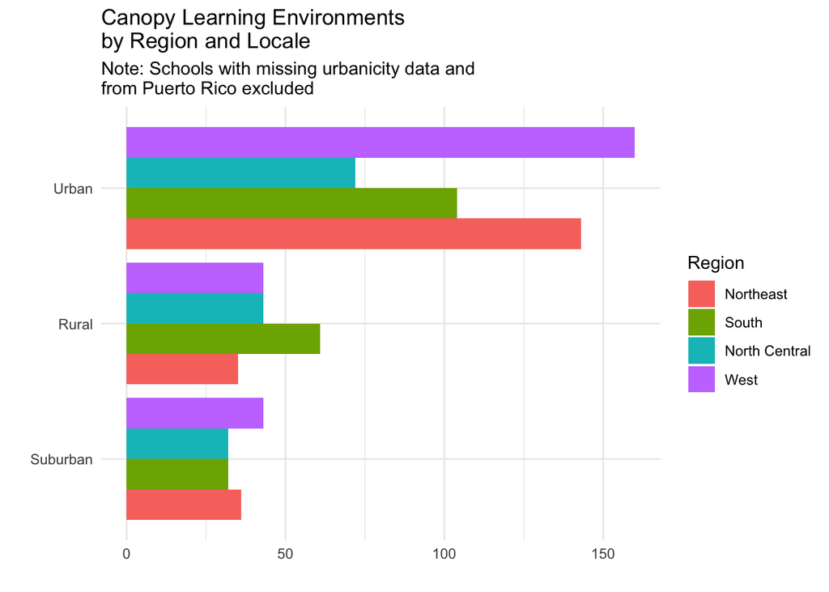

```r
full_region %>%
  filter(school_state != "Puerto Rico" & complete.cases(school_region, locale, school_state)) %>%
  dplyr::group_by(school_region, locale) %>%
  dplyr::summarize(counts = n()) %>%
  ggplot(aes(x = reorder(locale, counts), y = counts, fill = school_region)) +
  geom_col(position = "dodge") +
  theme(axis.text.x = element_text(angle = 45, hjust = 1)) +
  coord_flip() +
  theme_minimal() +
  labs(title = "Canopy Learning Environments\nby Region and Locale",
       subtitle = "Note: Schools with missing urbanicity data and \nfrom Puerto Rico excluded",
       x = "",
       y = "",
       fill = "Region")
```

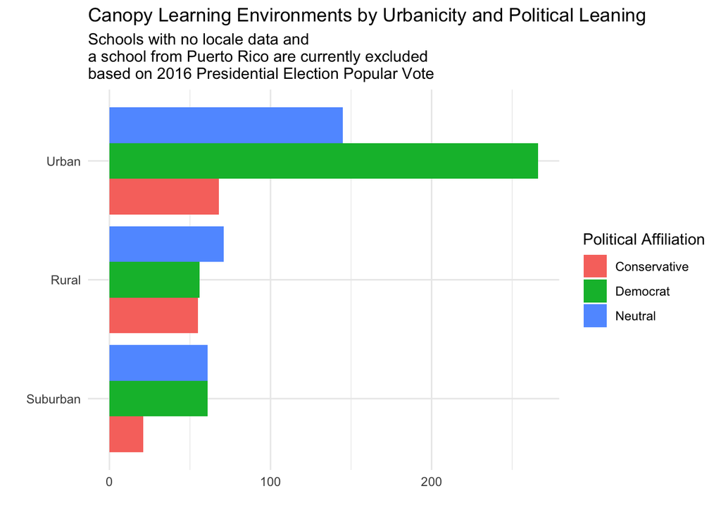

```r
full_region %>%
  filter(school_state != "Puerto Rico" & complete.cases(locale, Political_Affiliation, school_state)) %>%
  dplyr::group_by(Political_Affiliation, locale) %>%
  dplyr::summarize(counts = n()) %>%
  ggplot(aes(x = reorder(locale, counts), y = counts, fill = Political_Affiliation)) +
  geom_col(position = "dodge") +
  theme(axis.text.x = element_text(angle = 45, hjust = 1)) +
  coord_flip() +
  theme_minimal() +
  labs(title = "Canopy Learning Environments by Urbanicity and Political Leaning",
       subtitle = "Schools with no locale data and \na school from Puerto Rico are currently excluded \nbased on 2016 Presidential Election Popular Vote",
       x = "",
       y = "",
       fill = "Political Affiliation")
```

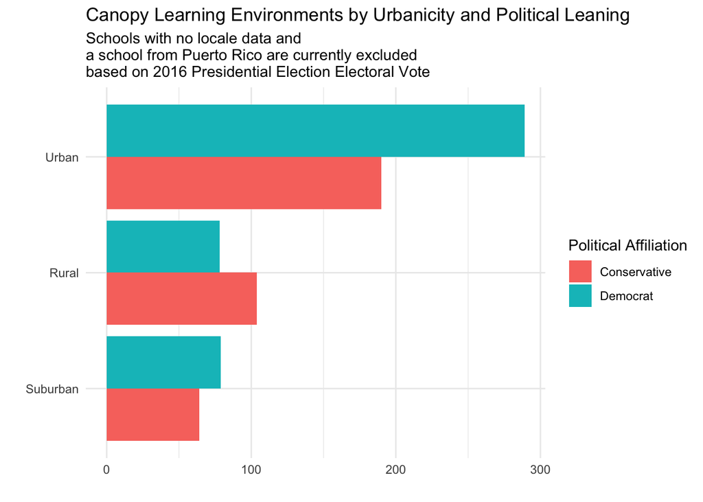

```r
full_region %>%
  filter(school_state != "Puerto Rico" & complete.cases(school_state, Political_Aff_2, locale)) %>%
  dplyr::group_by(Political_Aff_2, locale) %>%
  dplyr::summarize(counts = n()) %>%
  ggplot(aes(x = reorder(locale, counts), y = counts, fill = Political_Aff_2)) +
  geom_col(position = "dodge") +
  theme(axis.text.x = element_text(angle = 45, hjust = 1)) +
  coord_flip() +
  theme_minimal() +
  labs(title = "Canopy Learning Environments by Urbanicity and Political Leaning",
       subtitle = "Schools with no locale data and \na school from Puerto Rico are currently excluded \nbased on 2016 Presidential Election Electoral Vote",
       x = "",
       y = "",
       fill = "Political Affiliation")
```

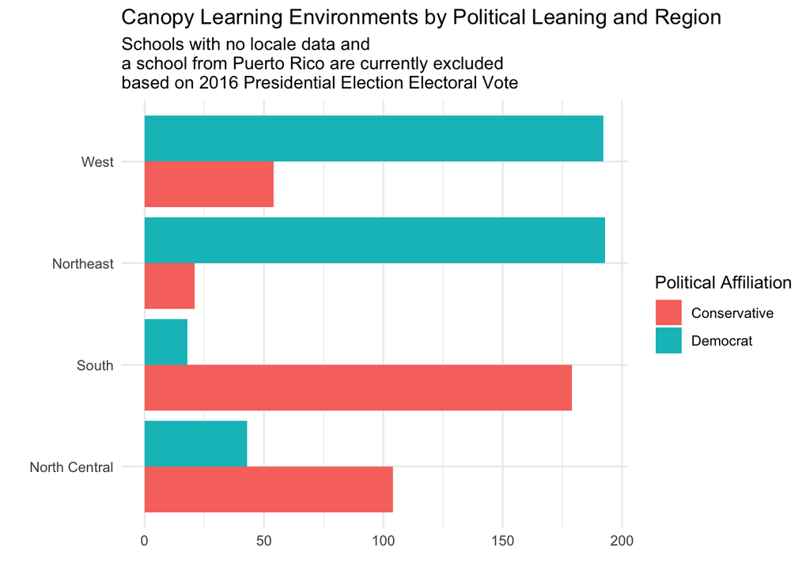

```r
full_region %>%
  filter(school_state != "Puerto Rico" & complete.cases(school_state, school_region, locale)) %>%
  dplyr::group_by(Political_Aff_2, school_region) %>%
  dplyr::summarize(counts = n()) %>%
  ggplot(aes(x = reorder(school_region, counts), y = counts, fill = Political_Aff_2)) +
  geom_col(position = "dodge") +
  theme(axis.text.x = element_text(angle = 45, hjust = 1)) +
  coord_flip() +
  theme_minimal() +
  labs(title = "Canopy Learning Environments by Political Leaning and Region",
       subtitle = "Schools with no locale data and \na school from Puerto Rico are currently excluded \nbased on 2016 Presidential Election Electoral Vote",
       x = "",
       y = "",
       fill = "Political Affiliation")
```

```r
# J - adding quick table for paper
tab_reg <- full_region %>%
  mutate(rate = rep(1, nrow(.))) %>%
  group_by(year, school_region) %>%
  dplyr::summarize(n = sum(rate))
datatable(tab_reg)
```

|  | year | school_region | n |
| --- | --- | --- | --- |
| 1 | 2019 | Northeast | 45 |
| 2 | 2019 | South | 56 |
| 3 | 2019 | North Central | 26 |
| 4 | 2019 | West | 46 |
| 5 | 2021 | Northeast | 62 |
| 6 | 2021 | South | 51 |
| 7 | 2021 | North Central | 50 |
| 8 | 2021 | West | 69 |
| 9 | 2022 | Northeast | 36 |
| 10 | 2022 | South | 35 |

[output cut: 8 more lines]

## Dsitribution Plot by Year

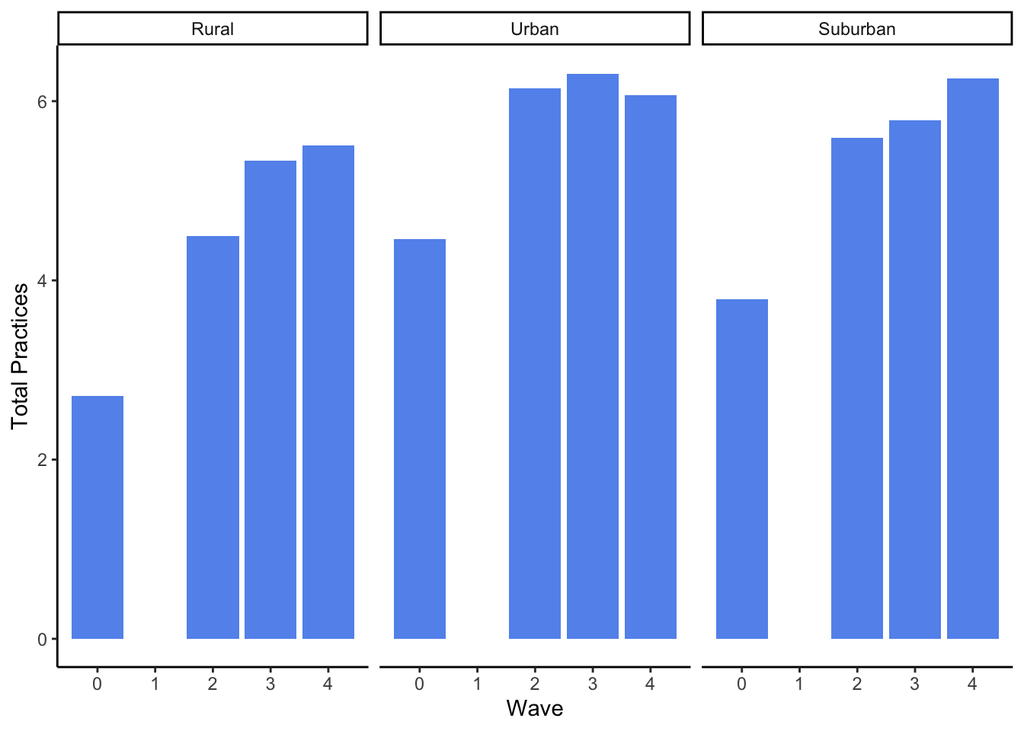

```r
full_region %>%
  filter(!is.na(locale) & complete.cases(school_state)) %>%
  group_by(locale) %>%
ggplot(aes(x = wave, y = prac_tot )) +
  geom_bar(stat = "summary", fun = "mean", fill="cornflowerblue") +
  facet_grid(~locale) +
  theme_classic()+
  labs(y = "Total Practices", x = "Wave")
```

## Descriptive Table

```r
datatable(round(describe(full_region[5:19], fast = TRUE, ranges = FALSE), digits = 2))
```

|  | vars | n | mean | sd | se |
| --- | --- | --- | --- | --- | --- |
| prac_culture | 1 | 817 | 0.65 | 0.48 | 0.02 |
| prac_sel_assess | 2 | 817 | 0.64 | 0.48 | 0.02 |
| prac_community | 3 | 817 | 0.6 | 0.49 | 0.02 |
| prac_mental | 4 | 817 | 0.67 | 0.47 | 0.02 |
| prac_restorative | 5 | 817 | 0.67 | 0.47 | 0.02 |
| prac_marginalized | 6 | 817 | 0.65 | 0.48 | 0.02 |
| prac_sel_curriculum | 7 | 817 | 0.42 | 0.49 | 0.02 |
| prac_sel_integrated | 8 | 817 | 0.68 | 0.47 | 0.02 |
| prac_resources | 9 | 817 | 0.45 | 0.5 | 0.02 |
| locale | 10 | 808 |  |  |  |

[output cut: 5 more lines]

## Missing Data

```r
library(misty)
library(naniar)

full_region$cbipoc_percent <- c(scale(full_region$bipoc_percent,  center=TRUE, scale=TRUE))
full_region$cfrpl_percent <- c(scale(full_region$frpl_percent,  center=TRUE, scale=TRUE))

full_mcar <- full_region %>%
  select(wave, frpl_percent, locale, bipoc_percent, prac_tot)

full_mcar$locale <- as.numeric(full_mcar$locale)

mcar_test(full_mcar)
```

```
## # A tibble: 1 × 4
##   statistic    df     p.value missing.patterns
##       <dbl> <dbl>       <dbl>            <int>
## 1      71.4    23 0.000000736                8
```

```r
na.descript(full_region)
```

```
##  Descriptive Statistics for Missing Data
##
##   No. of cases                817
##   No. of complete cases       676 (82.74%)
##   No. of incomplete cases     141 (17.26%)
##
##   No. of values             22059
##   No. of observed values    21584 (97.85%)
##   No. of missing values       475  (2.15%)
##
##   No. of variables             27
##   No. of missing values across all variables
##     Mean                    17.59  (2.15%)
##     SD                      40.27  (4.93%)
##     Minimum                  0.00  (0.00%)
##     P25                      0.00  (0.00%)
##     P75                      4.00  (0.49%)
##     Maximum                124.00 (15.18%)
```

```r
na.pattern (full_region)
```

```
##  Missing Data Pattern
##
##   Pattern   n    perc nces_id school_id school_name school_state prac_culture
##         1 676  82.74%       1         1           1            1            1
##         2   4   0.49%       1         1           1            1            1
##         3   9   1.10%       1         1           1            1            1
##         4  34   4.16%       1         1           1            1            1
##         5  85  10.40%       1         1           1            1            1
##         6   3   0.37%       1         1           1            1            1
##         7   1   0.12%       1         1           1            1            1
##         8   1   0.12%       1         1           1            1            1
##         9   4   0.49%       1         1           1            1            1
##           817 100.00%       0         0           0            0            0
##  prac_sel_assess prac_community prac_mental prac_restorative prac_marginalized
##                1              1           1                1                 1
```

[output cut: 53 more lines]

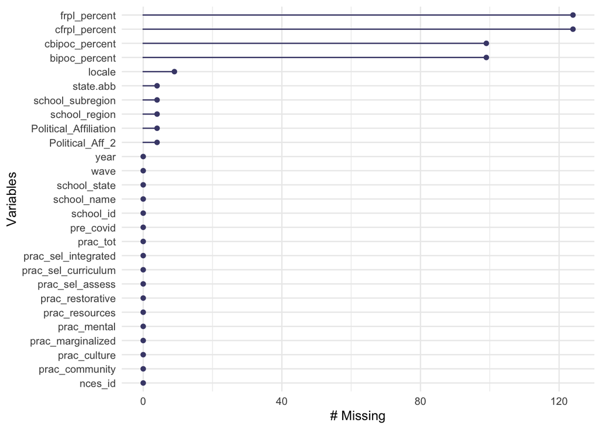

```r
gg_miss_var(full_region)
```

There is a difference between complete cases and partial cases. Code complete and partial data and run t tests to try to predict difference between cases. If there is a mean difference, we should add that as a control in the model.

Attrition analysis: examine schools that participated over all 4 waves Examine means test of the two groups and report that.

*Still unsure if this makes sense given Canopy’s design*

### Attrition Analysis

```r
# Group by school_id and determine if a school participated in all 4 waves
attrition_analysis <- full_region %>%
  group_by(school_name) %>%
  summarize(participated_all_waves = n_distinct(wave) == 4) %>%
  ungroup()

# Join the attrition analysis results to the original data
attrition_data <- full_region %>%
  inner_join(attrition_analysis, by = "school_name")

# Calculate means for the two groups and perform a t-test
means_comparison <- attrition_data %>%
  group_by(participated_all_waves) %>%
  summarize(mean_variable = mean(prac_tot))

# Perform the t-test manually
t_test_result <- t.test(attrition_data$prac_tot ~ attrition_data$participated_all_waves)

# Extract the p-value from the t-test result
p_value <- t_test_result$p.value

# Print the means and p-value
means_comparison
```

```
## # A tibble: 2 × 2
##   participated_all_waves mean_variable
##   <lgl>                          <dbl>
## 1 FALSE                           5.42
## 2 TRUE                            5.61
```

```r
cat("p-value:", p_value, "\n")
```

```
## p-value: 0.4796477
```

While I am still unsure if this is necessary, it does seem like there is not a significant difference between the two groups.

### Examining mean differences

```r
## Setting up the groups(Complete and incomplete data to examine mean differences)
full_region_All <- full_region %>%
  filter(!is.na(bipoc_percent) & !is.na(frpl_percent) & !is.na(locale) & !is.na(school_region))%>%
  mutate(group = 1) # schools with complete data are coded 1

full_region_miss <- full_region %>%
  filter(is.na(bipoc_percent) | is.na(frpl_percent) | is.na(locale) | is.na(school_region))%>%
  mutate(group=0) # schools with missing data are coded 0

full_mean_test <- full_join(full_region_All, full_region_miss) # rejoining the data
```

[output not shown]

```r
full_mean_test$group <- as.factor(full_mean_test$group)

## Testing the mean difference in total practices for complete and incomplete school data
t.test(prac_tot ~ group, data = full_mean_test)
```

```
##
##  Welch Two Sample t-test
##
## data:  prac_tot by group
## t = -0.75919, df = 208.17, p-value = 0.4486
## alternative hypothesis: true difference in means between group 0 and group 1 is not equal to 0
## 95 percent confidence interval:
##  -0.6099467  0.2707802
## sample estimates:
## mean in group 0 mean in group 1
##        5.297872        5.467456
```

```r
# This suggests that the difference in practice total is not significant between school groups.

# To double check because our data is not exactly normal, here is the wilcox test
wilcox.test(prac_tot ~ group, data = full_mean_test)
```

```
##
##  Wilcoxon rank sum test with continuity correction
##
## data:  prac_tot by group
## W = 45150, p-value = 0.3219
## alternative hypothesis: true location shift is not equal to 0
```

```r
# Is in agreement with Welch's test that the difference in practice totals is not significant
```

Based on an examination of the mean differences between groups of complete data schools and missing data schools, it seems like there is no difference in the mean total practices of schools with missing frpl and bipoc data compared to schools with complete data.

```r
## Examining the locale data for missing and complete school data
locale_count_complete <- full_mean_test %>% filter(group == 1) %>% dplyr::count(locale)
locale_count_complete$prct_locale <- round((locale_count_complete$n/676)*100,digits = 2)
datatable(locale_count_complete) # Percent of each locale for complete schools data
```

|  | locale | n | prct_locale |
| --- | --- | --- | --- |
| 1 | Rural | 161 | 23.82 |
| 2 | Urban | 395 | 58.43 |
| 3 | Suburban | 120 | 17.75 |

```r
locale_count_miss <- full_mean_test %>% filter(group == 0) %>% dplyr::count(locale)
locale_count_miss$prct_locale <- round((locale_count_miss$n/141)*100, digits = 2)
datatable(locale_count_miss) # percent of each locale for incomplete schools data
```

|  | locale | n | prct_locale |
| --- | --- | --- | --- |
| 1 | Rural | 21 | 14.89 |
| 2 | Urban | 87 | 61.7 |
| 3 | Suburban | 24 | 17.02 |
| 4 |  | 9 | 6.38 |

```r
full_mean_test$locale <- as.numeric(full_mean_test$locale) # need to change locale to a factor to examine the difference here.

t.test(locale ~ group, data = full_mean_test)
```

```
##
##  Welch Two Sample t-test
##
## data:  locale by group
## t = 1.4719, df = 197.66, p-value = 0.1426
## alternative hypothesis: true difference in means between group 0 and group 1 is not equal to 0
## 95 percent confidence interval:
##  -0.02833029  0.19508661
## sample estimates:
## mean in group 0 mean in group 1
##        2.022727        1.939349
```

```r
# Suggests that the difference in location is not significant by locale between the complete and incomplete data

wilcox.test(locale ~ group, data = full_mean_test)
```

```
##
##  Wilcoxon rank sum test with continuity correction
##
## data:  locale by group
## W = 47664, p-value = 0.157
## alternative hypothesis: true location shift is not equal to 0
```

```r
# It agrees with the t test and suggests that there is not a significant difference between the locale complete and incomplete data
```

# Modeling

## Fixed Effects

This is how he did assignment 3 where we first examined if practices changed overtime in general without any predictors.

```r
library(sjPlot)
library(lme4)
library(performance)
library(interactions)
library(modelsummary)

# Let's make the rural south the reference since I hypothesize that they would have the least amount of social justice practices.
full_region$school_region <- relevel(full_region$school_region, ref = "South")


GLMMCond <- glmer(prac_tot ~ 1 + wave + (1|school_id),
                  family = poisson,
                  data = full_region)
summary(GLMMCond)
```

```
## Generalized linear mixed model fit by maximum likelihood (Laplace
##   Approximation) [glmerMod]
##  Family: poisson  ( log )
## Formula: prac_tot ~ 1 + wave + (1 | school_id)
##    Data: full_region
##
##      AIC      BIC   logLik deviance df.resid
##   3749.0   3763.2  -1871.5   3743.0      814
##
## Scaled residuals:
##      Min       1Q   Median       3Q      Max
## -2.11731 -0.47903  0.09381  0.49770  1.70407
##
## Random effects:
##  Groups    Name        Variance Std.Dev.
##  school_id (Intercept) 0.06896  0.2626
## Number of obs: 817, groups:  school_id, 492
##
## Fixed effects:
##             Estimate Std. Error z value Pr(>|z|)
## (Intercept)  1.37023    0.03787  36.187   <2e-16 ***
## wave         0.10980    0.01199   9.157   <2e-16 ***
## ---
## Signif. codes:  0 '***' 0.001 '**' 0.01 '*' 0.05 '.' 0.1 ' ' 1
##
## Correlation of Fixed Effects:
##      (Intr)
## wave -0.832
```

```r
tab_model(GLMMCond)
```

|  | prac tot |  |  |
| --- | --- | --- | --- |
| Predictors | Incidence Rate Ratios | CI | p |
| (Intercept) | 3.94 | 3.65 – 4.24 | **<0.001** |
| wave | 1.12 | 1.09 – 1.14 | **<0.001** |
| Random Effects |  |  |  |
| σ<sup>2</sup> | 0.18 |  |  |
| τ<sub>00</sub> <sub>school_id</sub> | 0.07 |  |  |
| ICC | 0.28 |  |  |
| N <sub>school_id</sub> | 492 |  |  |
| Observations | 817 |  |  |
| Marginal R<sup>2</sup> / Conditional R<sup>2</sup> | 0.094 / 0.348 |  |  |

**ICC: 0.28**

Total observations 817 (Before we have missing data in the predictors)

In this case, wave does seem to be significant.

## Model with predictors

### No interaction.

Here we are adding in locale, percent bipoc, and percent frpl as predictors in our model.

```r
GLMMfix <- glmer(prac_tot ~ 1 + wave + locale + cbipoc_percent + cfrpl_percent + (1|school_id),
                  family = poisson,
                  data = full_region)

## No interaction term here
summary(GLMMfix)
```

```
## Generalized linear mixed model fit by maximum likelihood (Laplace
##   Approximation) [glmerMod]
##  Family: poisson  ( log )
## Formula: prac_tot ~ 1 + wave + locale + cbipoc_percent + cfrpl_percent +
##     (1 | school_id)
##    Data: full_region
##
##      AIC      BIC   logLik deviance df.resid
##   3114.5   3146.1  -1550.2   3100.5      673
##
## Scaled residuals:
##     Min      1Q  Median      3Q     Max
## -2.2418 -0.5245  0.1025  0.5444  1.9458
##
## Random effects:
##  Groups    Name        Variance Std.Dev.
##  school_id (Intercept) 0.04897  0.2213
## Number of obs: 680, groups:  school_id, 435
##
## Fixed effects:
##                Estimate Std. Error z value Pr(>|z|)
## (Intercept)     1.24763    0.05965  20.917  < 2e-16 ***
## wave            0.10649    0.01299   8.195 2.51e-16 ***
## localeUrban     0.16830    0.05926   2.840  0.00451 **
## localeSuburban  0.17282    0.06637   2.604  0.00921 **
## cbipoc_percent  0.03352    0.02909   1.152  0.24918
## cfrpl_percent   0.04209    0.02514   1.674  0.09407 .
## ---
## Signif. codes:  0 '***' 0.001 '**' 0.01 '*' 0.05 '.' 0.1 ' ' 1
##
## Correlation of Fixed Effects:
##             (Intr) wave   lclUrb lclSbr cbpc_p
## wave        -0.572
## localeUrban -0.693 -0.042
## localeSbrbn -0.559 -0.013  0.603
## cbipc_prcnt  0.350 -0.018 -0.518 -0.246
## cfrpl_prcnt -0.156 -0.089  0.253  0.240 -0.586
```

```r
tab_model(GLMMfix)
```

|  | prac tot |  |  |
| --- | --- | --- | --- |
| Predictors | Incidence Rate Ratios | CI | p |
| (Intercept) | 3.48 | 3.10 – 3.91 | **<0.001** |
| wave | 1.11 | 1.08 – 1.14 | **<0.001** |
| locale [Urban] | 1.18 | 1.05 – 1.33 | **0.005** |
| locale [Suburban] | 1.19 | 1.04 – 1.35 | **0.009** |
| cbipoc percent | 1.03 | 0.98 – 1.09 | 0.249 |
| cfrpl percent | 1.04 | 0.99 – 1.10 | 0.094 |
| Random Effects |  |  |  |
| σ<sup>2</sup> | 0.18 |  |  |
| τ<sub>00</sub> <sub>school_id</sub> | 0.05 |  |  |
| ICC | 0.22 |  |  |
| N <sub>school_id</sub> | 435 |  |  |
| Observations | 680 |  |  |
| Marginal R<sup>2</sup> / Conditional R<sup>2</sup> | 0.154 / 0.337 |  |  |

### Interaction term

This first model looks at the interaction between locale and school region but does not take into consideration wave.

```r
GLMMfix_inter <- glmer(prac_tot ~ 1 + wave +
                         locale +
                         school_region +
                         locale*school_region +
                         cbipoc_percent +
                         cfrpl_percent + (1|school_id),
                  family = poisson,
                  data = full_region)

## No interaction term here
summary(GLMMfix_inter)
```

```
## Generalized linear mixed model fit by maximum likelihood (Laplace
##   Approximation) [glmerMod]
##  Family: poisson  ( log )
## Formula:
## prac_tot ~ 1 + wave + locale + school_region + locale * school_region +
##     cbipoc_percent + cfrpl_percent + (1 | school_id)
##    Data: full_region
##
##      AIC      BIC   logLik deviance df.resid
##   3089.3   3161.6  -1528.7   3057.3      660
##
## Scaled residuals:
##      Min       1Q   Median       3Q      Max
## -2.18450 -0.56948  0.08228  0.56020  1.95068
##
## Random effects:
##  Groups    Name        Variance Std.Dev.
##  school_id (Intercept) 0.03942  0.1985
## Number of obs: 676, groups:  school_id, 431
##
## Fixed effects:
##                                           Estimate Std. Error z value Pr(>|z|)
## (Intercept)                                1.27589    0.07883  16.185  < 2e-16
## wave                                       0.10529    0.01303   8.083 6.31e-16
## localeUrban                               -0.04130    0.09636  -0.429   0.6683
## localeSuburban                             0.08284    0.11661   0.710   0.4775
## school_regionNortheast                    -0.03575    0.13090  -0.273   0.7847
## school_regionNorth Central                -0.02618    0.11363  -0.230   0.8178
## school_regionWest                         -0.01474    0.11280  -0.131   0.8960
## cbipoc_percent                             0.03720    0.03001   1.239   0.2152
## cfrpl_percent                              0.03538    0.02542   1.392   0.1639
## localeUrban:school_regionNortheast         0.25121    0.15291   1.643   0.1004
## localeSuburban:school_regionNortheast     -0.13112    0.19503  -0.672   0.5014
## localeUrban:school_regionNorth Central     0.23664    0.14299   1.655   0.0979
## localeSuburban:school_regionNorth Central  0.30848    0.17148   1.799   0.0720
## localeUrban:school_regionWest              0.28548    0.13311   2.145   0.0320
## localeSuburban:school_regionWest           0.10051    0.16499   0.609   0.5424
##
## (Intercept)                               ***
## wave                                      ***
## localeUrban
## localeSuburban
## school_regionNortheast
## school_regionNorth Central
## school_regionWest
## cbipoc_percent
## cfrpl_percent
## localeUrban:school_regionNortheast
## localeSuburban:school_regionNortheast
## localeUrban:school_regionNorth Central    .
## localeSuburban:school_regionNorth Central .
## localeUrban:school_regionWest             *
## localeSuburban:school_regionWest
## ---
## Signif. codes:  0 '***' 0.001 '**' 0.01 '*' 0.05 '.' 0.1 ' ' 1
## optimizer (Nelder_Mead) convergence code: 0 (OK)
## Model failed to converge with max|grad| = 0.0412603 (tol = 0.002, component 1)
```

```r
tab_model(GLMMfix_inter)
```

|  | prac tot |  |  |
| --- | --- | --- | --- |
| Predictors | Incidence Rate Ratios | CI | p |
| (Intercept) | 3.58 | 3.07 – 4.18 | **<0.001** |
| wave | 1.11 | 1.08 – 1.14 | **<0.001** |
| locale [Urban] | 0.96 | 0.79 – 1.16 | 0.668 |
| locale [Suburban] | 1.09 | 0.86 – 1.37 | 0.477 |
| school region [Northeast] | 0.96 | 0.75 – 1.25 | 0.785 |
| school region [North Central] | 0.97 | 0.78 – 1.22 | 0.818 |
| school region [West] | 0.99 | 0.79 – 1.23 | 0.896 |
| cbipoc percent | 1.04 | 0.98 – 1.10 | 0.215 |
| cfrpl percent | 1.04 | 0.99 – 1.09 | 0.164 |
| locale [Urban] × school region [Northeast] | 1.29 | 0.95 – 1.73 | 0.100 |
| locale [Suburban] × school region [Northeast] | 0.88 | 0.60 – 1.29 | 0.501 |
| locale [Urban] × school region [North Central] | 1.27 | 0.96 – 1.68 | 0.098 |
| locale [Suburban] × school region [North Central] | 1.36 | 0.97 – 1.91 | 0.072 |
| locale [Urban] × school region [West] | 1.33 | 1.02 – 1.73 | **0.032** |
| locale [Suburban] × school region [West] | 1.11 | 0.80 – 1.53 | 0.542 |
| Random Effects |  |  |  |
| σ<sup>2</sup> | 0.18 |  |  |
| τ<sub>00</sub> <sub>school_id</sub> | 0.04 |  |  |
| ICC | 0.18 |  |  |
| N <sub>school_id</sub> | 431 |  |  |
| Observations | 676 |  |  |
| Marginal R<sup>2</sup> / Conditional R<sup>2</sup> | 0.193 / 0.340 |  |  |

*I need help interpreting this*

## Covid time varying covariate

This adds in the time varying covariate of covid but still does not have the wave interaction term.

```r
GLMMfix_covid <- glmer(prac_tot ~ 1 + wave + locale +
                         school_region +
                         locale*school_region +
                         cbipoc_percent +
                         cfrpl_percent +
                         pre_covid + (1|school_id),
                  family = poisson,
                  data = full_region)

## No interaction term here
summary(GLMMfix_covid)
```

```
## Generalized linear mixed model fit by maximum likelihood (Laplace
##   Approximation) [glmerMod]
##  Family: poisson  ( log )
## Formula:
## prac_tot ~ 1 + wave + locale + school_region + locale * school_region +
##     cbipoc_percent + cfrpl_percent + pre_covid + (1 | school_id)
##    Data: full_region
##
##      AIC      BIC   logLik deviance df.resid
##   3079.6   3156.4  -1522.8   3045.6      659
##
## Scaled residuals:
##     Min      1Q  Median      3Q     Max
## -2.2835 -0.5391  0.1207  0.5533  2.1538
##
## Random effects:
##  Groups    Name        Variance Std.Dev.
##  school_id (Intercept) 0.03695  0.1922
## Number of obs: 676, groups:  school_id, 431
##
## Fixed effects:
##                                           Estimate Std. Error z value Pr(>|z|)
## (Intercept)                                1.51611    0.10445  14.515  < 2e-16
## wave                                       0.03925    0.02321   1.691 0.090760
## localeUrban                               -0.04649    0.09588  -0.485 0.627760
## localeSuburban                             0.06304    0.11594   0.544 0.586613
## school_regionNortheast                    -0.03041    0.12987  -0.234 0.814862
## school_regionNorth Central                -0.04924    0.11289  -0.436 0.662689
## school_regionWest                         -0.01888    0.11210  -0.168 0.866261
## cbipoc_percent                             0.04801    0.03000   1.600 0.109528
## cfrpl_percent                              0.02872    0.02539   1.131 0.257952
## pre_covid                                 -0.30227    0.08850  -3.415 0.000637
## localeUrban:school_regionNortheast         0.24234    0.15177   1.597 0.110321
## localeSuburban:school_regionNortheast     -0.10165    0.19399  -0.524 0.600281
## localeUrban:school_regionNorth Central     0.24471    0.14189   1.725 0.084598
## localeSuburban:school_regionNorth Central  0.34231    0.17035   2.009 0.044491
## localeUrban:school_regionWest              0.27329    0.13236   2.065 0.038945
## localeSuburban:school_regionWest           0.10229    0.16391   0.624 0.532579
##
## (Intercept)                               ***
## wave                                      .
## localeUrban
## localeSuburban
## school_regionNortheast
## school_regionNorth Central
## school_regionWest
## cbipoc_percent
## cfrpl_percent
## pre_covid                                 ***
## localeUrban:school_regionNortheast
## localeSuburban:school_regionNortheast
## localeUrban:school_regionNorth Central    .
## localeSuburban:school_regionNorth Central *
## localeUrban:school_regionWest             *
## localeSuburban:school_regionWest
## ---
## Signif. codes:  0 '***' 0.001 '**' 0.01 '*' 0.05 '.' 0.1 ' ' 1
## optimizer (Nelder_Mead) convergence code: 0 (OK)
## Model failed to converge with max|grad| = 0.0570796 (tol = 0.002, component 1)
```

```r
tab_model(GLMMfix_covid)
```

|  | prac tot |  |  |
| --- | --- | --- | --- |
| Predictors | Incidence Rate Ratios | CI | p |
| (Intercept) | 4.55 | 3.71 – 5.59 | **<0.001** |
| wave | 1.04 | 0.99 – 1.09 | 0.091 |
| locale [Urban] | 0.95 | 0.79 – 1.15 | 0.628 |
| locale [Suburban] | 1.07 | 0.85 – 1.34 | 0.587 |
| school region [Northeast] | 0.97 | 0.75 – 1.25 | 0.815 |
| school region [North Central] | 0.95 | 0.76 – 1.19 | 0.663 |
| school region [West] | 0.98 | 0.79 – 1.22 | 0.866 |
| cbipoc percent | 1.05 | 0.99 – 1.11 | 0.110 |
| cfrpl percent | 1.03 | 0.98 – 1.08 | 0.258 |
| pre covid | 0.74 | 0.62 – 0.88 | **0.001** |
| locale [Urban] × school region [Northeast] | 1.27 | 0.95 – 1.72 | 0.110 |
| locale [Suburban] × school region [Northeast] | 0.90 | 0.62 – 1.32 | 0.600 |
| locale [Urban] × school region [North Central] | 1.28 | 0.97 – 1.69 | 0.085 |
| locale [Suburban] × school region [North Central] | 1.41 | 1.01 – 1.97 | **0.044** |
| locale [Urban] × school region [West] | 1.31 | 1.01 – 1.70 | **0.039** |
| locale [Suburban] × school region [West] | 1.11 | 0.80 – 1.53 | 0.533 |
| Random Effects |  |  |  |
| σ<sup>2</sup> | 0.18 |  |  |
| τ<sub>00</sub> <sub>school_id</sub> | 0.04 |  |  |
| ICC | 0.17 |  |  |
| N <sub>school_id</sub> | 431 |  |  |
| Observations | 676 |  |  |
| Marginal R<sup>2</sup> / Conditional R<sup>2</sup> | 0.214 / 0.350 |  |  |

## Model check Conditional

Is this any better than the unconditional model?

```r
AIC(GLMMCond,GLMMfix, GLMMfix_inter, GLMMfix_covid)
```

```
##               df      AIC
## GLMMCond       3 3749.045
## GLMMfix        7 3114.473
## GLMMfix_inter 16 3089.319
## GLMMfix_covid 17 3079.633
```

```r
BIC(GLMMCond,GLMMfix, GLMMfix_inter, GLMMfix_covid)
```

```
##               df      BIC
## GLMMCond       3 3763.162
## GLMMfix        7 3146.128
## GLMMfix_inter 16 3161.578
## GLMMfix_covid 17 3156.408
```

## Model Interactions

**Locale x Wave**  
**Locale X Region**  
**Region X Wave**

The previous model did have an interaction effect, but did not have the interaction of wave. In this model we have the interaction between wave and locale, wave and school region, and locale and school region but not of percent bipoc percent frpl, and pre_covid.

```r
GLMMfix_wave_inter <- glmer(prac_tot ~ 1 + wave +
                    locale +
                    school_region +
                    wave*school_region +
                    locale*school_region +
                    cbipoc_percent +
                    cfrpl_percent +
                    pre_covid +
                    locale*wave +
                    (1|school_id),
                  family = poisson,
                  data = full_region)
summary(GLMMfix_wave_inter)
```

```
## Generalized linear mixed model fit by maximum likelihood (Laplace
##   Approximation) [glmerMod]
##  Family: poisson  ( log )
## Formula: prac_tot ~ 1 + wave + locale + school_region + wave * school_region +
##     locale * school_region + cbipoc_percent + cfrpl_percent +
##     pre_covid + locale * wave + (1 | school_id)
##    Data: full_region
##
##      AIC      BIC   logLik deviance df.resid
##   3072.8   3172.1  -1514.4   3028.8      654
##
## Scaled residuals:
##      Min       1Q   Median       3Q      Max
## -2.28953 -0.55734  0.09919  0.55022  2.89879
##
## Random effects:
##  Groups    Name        Variance Std.Dev.
##  school_id (Intercept) 0.03118  0.1766
## Number of obs: 676, groups:  school_id, 431
##
## Fixed effects:
##                                            Estimate Std. Error z value Pr(>|z|)
## (Intercept)                                1.275676   0.127873   9.976  < 2e-16
## wave                                       0.150193   0.039574   3.795 0.000148
## localeUrban                                0.195105   0.128680   1.516 0.129467
## localeSuburban                             0.251469   0.155216   1.620 0.105207
## school_regionNortheast                     0.005196   0.161738   0.032 0.974369
## school_regionNorth Central                -0.153540   0.161459  -0.951 0.341630
## school_regionWest                          0.065125   0.144820   0.450 0.652927
## cbipoc_percent                             0.039772   0.029730   1.338 0.180964
## cfrpl_percent                              0.034800   0.025339   1.373 0.169634
## pre_covid                                 -0.296586   0.088752  -3.342 0.000833
## wave:school_regionNortheast               -0.040151   0.036744  -1.093 0.274516
## wave:school_regionNorth Central            0.007099   0.042346   0.168 0.866860
## wave:school_regionWest                    -0.056369   0.035461  -1.590 0.111925
## localeUrban:school_regionNortheast         0.318797   0.150279   2.121 0.033891
## localeSuburban:school_regionNortheast     -0.051093   0.192667  -0.265 0.790866
## localeUrban:school_regionNorth Central     0.325034   0.140441   2.314 0.020647
## localeSuburban:school_regionNorth Central  0.427977   0.168492   2.540 0.011084
## localeUrban:school_regionWest              0.340934   0.131134   2.600 0.009325
```

[output cut: 14 more lines]

```
## wave:school_regionNortheast
## wave:school_regionNorth Central
## wave:school_regionWest
## localeUrban:school_regionNortheast        *
## localeSuburban:school_regionNortheast
## localeUrban:school_regionNorth Central    *
## localeSuburban:school_regionNorth Central *
## localeUrban:school_regionWest             **
## localeSuburban:school_regionWest
## wave:localeUrban                          **
## wave:localeSuburban                       *
## ---
## Signif. codes:  0 '***' 0.001 '**' 0.01 '*' 0.05 '.' 0.1 ' ' 1
## optimizer (Nelder_Mead) convergence code: 0 (OK)
## Model failed to converge with max|grad| = 0.0801663 (tol = 0.002, component 1)
```

```r
tab_model(GLMMfix_wave_inter)
```

|  | prac tot |  |  |
| --- | --- | --- | --- |
| Predictors | Incidence Rate Ratios | CI | p |
| (Intercept) | 3.58 | 2.79 – 4.60 | **<0.001** |
| wave | 1.16 | 1.08 – 1.26 | **<0.001** |
| locale [Urban] | 1.22 | 0.94 – 1.56 | 0.129 |
| locale [Suburban] | 1.29 | 0.95 – 1.74 | 0.105 |
| school region [Northeast] | 1.01 | 0.73 – 1.38 | 0.974 |
| school region [North Central] | 0.86 | 0.63 – 1.18 | 0.342 |
| school region [West] | 1.07 | 0.80 – 1.42 | 0.653 |
| cbipoc percent | 1.04 | 0.98 – 1.10 | 0.181 |
| cfrpl percent | 1.04 | 0.99 – 1.09 | 0.170 |
| pre covid | 0.74 | 0.62 – 0.88 | **0.001** |
| wave × school region [Northeast] | 0.96 | 0.89 – 1.03 | 0.275 |
| wave × school region [North Central] | 1.01 | 0.93 – 1.09 | 0.867 |
| wave × school region [West] | 0.95 | 0.88 – 1.01 | 0.112 |
| locale [Urban] × school region [Northeast] | 1.38 | 1.02 – 1.85 | **0.034** |
| locale [Suburban] × school region [Northeast] | 0.95 | 0.65 – 1.39 | 0.791 |
| locale [Urban] × school region [North Central] | 1.38 | 1.05 – 1.82 | **0.021** |
| locale [Suburban] × school region [North Central] | 1.53 | 1.10 – 2.13 | **0.011** |
| locale [Urban] × school region [West] | 1.41 | 1.09 – 1.82 | **0.009** |
| locale [Suburban] × school region [West] | 1.19 | 0.87 – 1.64 | 0.275 |
| wave × locale [Urban] | 0.90 | 0.84 – 0.96 | **0.002** |
| wave × locale [Suburban] | 0.91 | 0.84 – 1.00 | **0.039** |
| Random Effects |  |  |  |
| σ<sup>2</sup> | 0.18 |  |  |
| τ<sub>00</sub> <sub>school_id</sub> | 0.03 |  |  |
| ICC | 0.15 |  |  |
| N <sub>school_id</sub> | 431 |  |  |
| Observations | 676 |  |  |
| Marginal R<sup>2</sup> / Conditional R<sup>2</sup> | 0.252 / 0.364 |  |  |

## Model check Interaction

Is this any better than the model without the interaction term?

```r
AIC(GLMMfix_covid,GLMMfix_wave_inter)
```

```
##                    df      AIC
## GLMMfix_covid      17 3079.633
## GLMMfix_wave_inter 22 3072.792
```

```r
BIC(GLMMfix_covid,GLMMfix_wave_inter)
```

```
##                    df      BIC
## GLMMfix_covid      17 3156.408
## GLMMfix_wave_inter 22 3172.148
```

```r
test_lrt(GLMMfix_covid,GLMMfix_wave_inter)
```

```
## # Likelihood-Ratio-Test (LRT) for Model Comparison (ML-estimator)
##
## Name               |    Model | df | df_diff |  Chi2 |     p
## ------------------------------------------------------------
## GLMMfix_covid      | glmerMod | 17 |         |       |
## GLMMfix_wave_inter | glmerMod | 22 |       5 | 16.84 | 0.005
```

Based on AIC the model with the interaction term is a better model but barely, BIC shows the opposite, but the test shows that the model with the interaction term is better: p = 0.005.

# Plots

**Not using a model**

## Locale and Wave

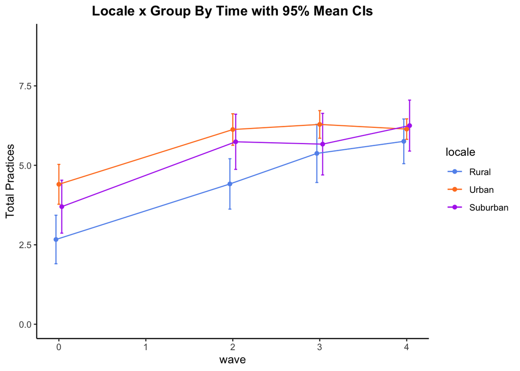

```r
library(Rmisc)

localegg <- summarySE(na.omit(full_region), measurevar="prac_tot", groupvars=c("locale","wave"))

localegg$wave<-as.numeric(localegg$wave)

# The errorbars overlapped, so use position_dodge to move them horizontally
pd <- position_dodge(0.1) # move them .05 to the left and right

# Use 95% confidence interval instead of SEM

ggplot(localegg, aes(x=wave, y=prac_tot, color=locale)) +
  geom_errorbar(aes(ymin=prac_tot-ci, ymax=prac_tot+ci), width=.1, position=pd) +
  ylab("Total Practices") +
  ylim(0,9) +
  geom_line(position=pd) +
  geom_point(position=pd) + theme_classic() +
  scale_color_manual(values=c("cornflowerblue", "chocolate1", "darkorchid2", "seagreen2")) +
  ggtitle("Locale x Group By Time with 95% Mean CIs") +
  theme(plot.title = element_text(hjust = 0.5, lineheight=.8, face="bold"))
```

## Locale, Wave, & Region

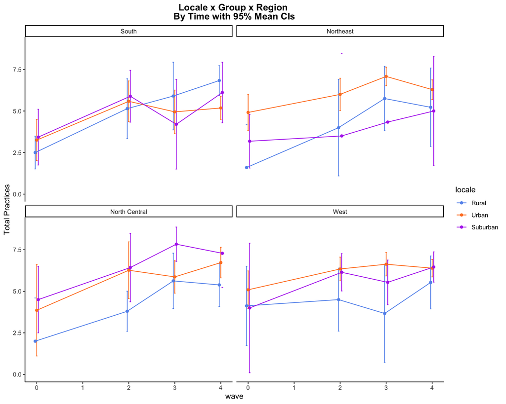

```r
localegg2 <- summarySE(na.omit(full_region), measurevar="prac_tot", groupvars=c("locale","wave", "school_region"))

localegg2$wave<-as.numeric(localegg2$wave)

# Use 95% confidence interval instead of SEM

ggplot(localegg2, aes(x=wave, y=prac_tot, color=locale)) +
  geom_errorbar(aes(ymin=prac_tot-ci, ymax=prac_tot+ci), width=.1, position=pd) +
  ylab("Total Practices") +
  ylim(0,9) +
  facet_wrap(~school_region) +
  geom_line(position=pd) +
  geom_point(position=pd) + theme_classic() +
  scale_color_manual(values=c("cornflowerblue", "chocolate1", "darkorchid2", "seagreen2")) +
  ggtitle("Locale x Group x Region \nBy Time with 95% Mean CIs") +
  theme(plot.title = element_text(hjust = 0.5, lineheight=.8, face="bold"))
```

## No Interaction Model

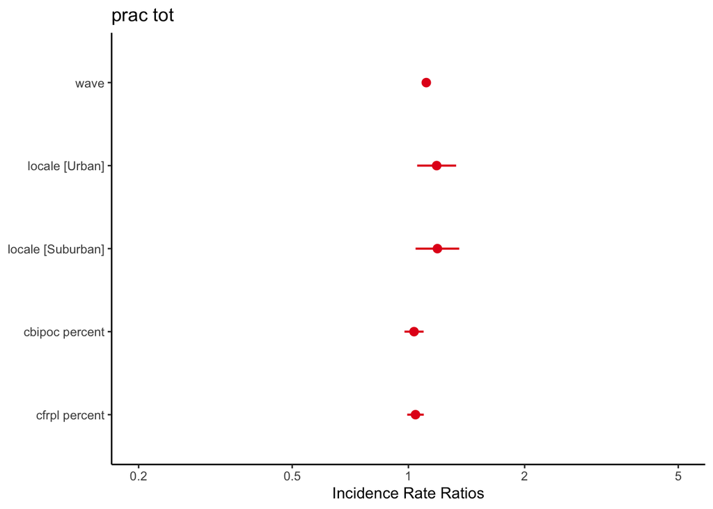

```r
plot_model(GLMMfix) + theme_classic ()
```

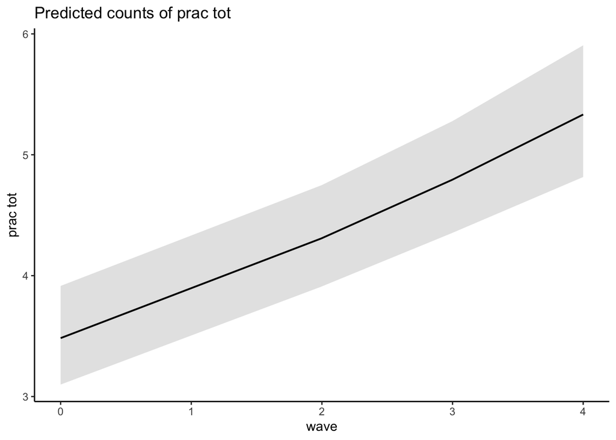

```r
plot_model(GLMMfix,type = "eff")$wave + theme_classic () # plot the effect of Time (Wave)
```

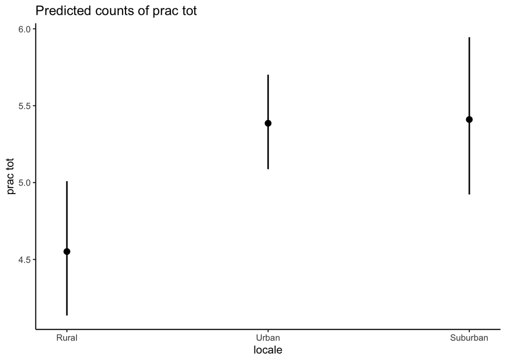

```r
plot_model(GLMMfix,type = "eff")$locale + theme_classic () # plot the effect of locale
```

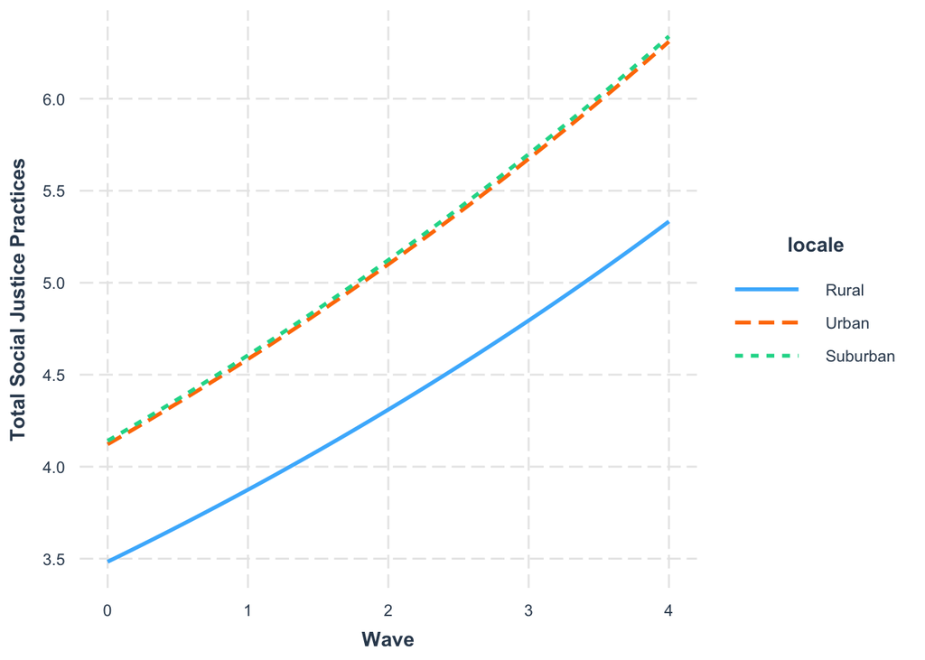

```r
interact_plot(model=GLMMfix, pred = wave, modx = locale)+
  labs(x = "Wave", y = "Total Social Justice Practices") # Enter the predictor of growth in the final model
```

## Interaction Model

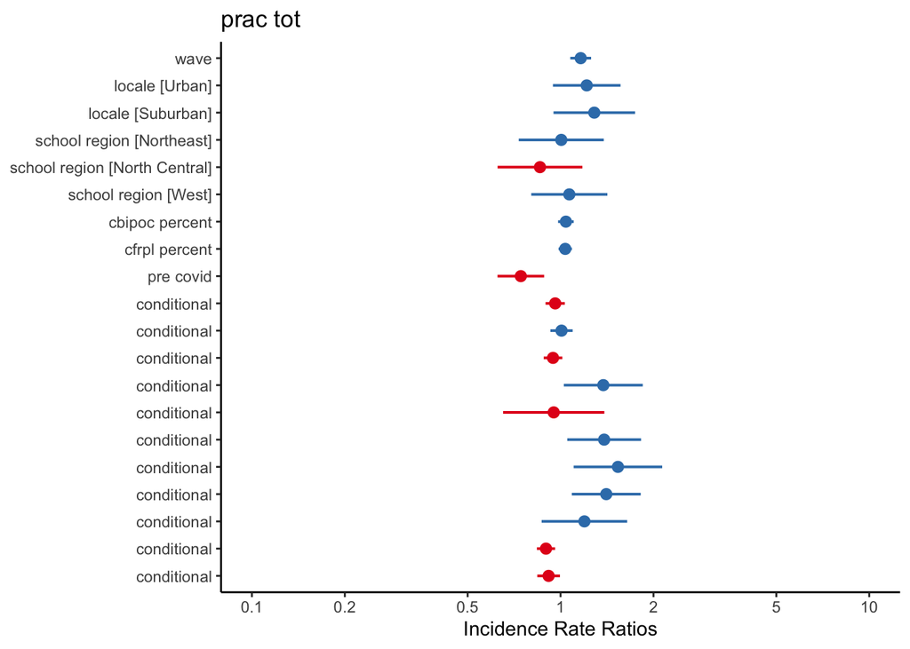

```r
plot_model(GLMMfix_wave_inter) + theme_classic ()
```

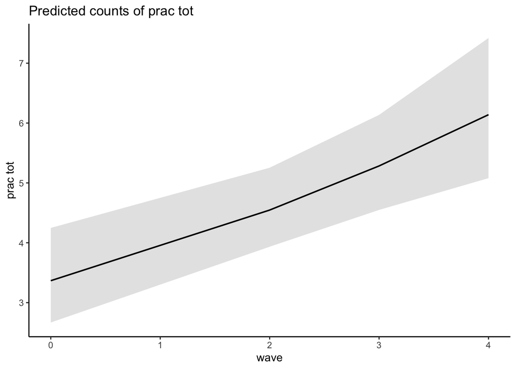

```r
plot_model(GLMMfix_wave_inter,type = "eff")$wave + theme_classic () # plot the effect of Time (Wave)
```

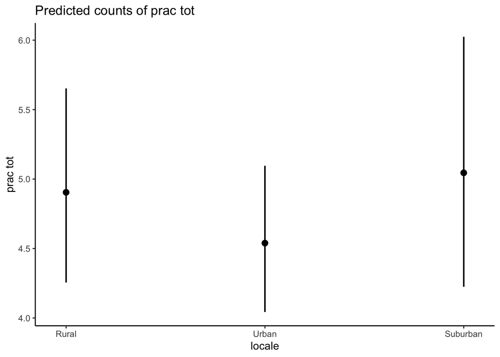

```r
plot_model(GLMMfix_wave_inter,type = "eff")$locale + theme_classic () # plot the effect of locale
```

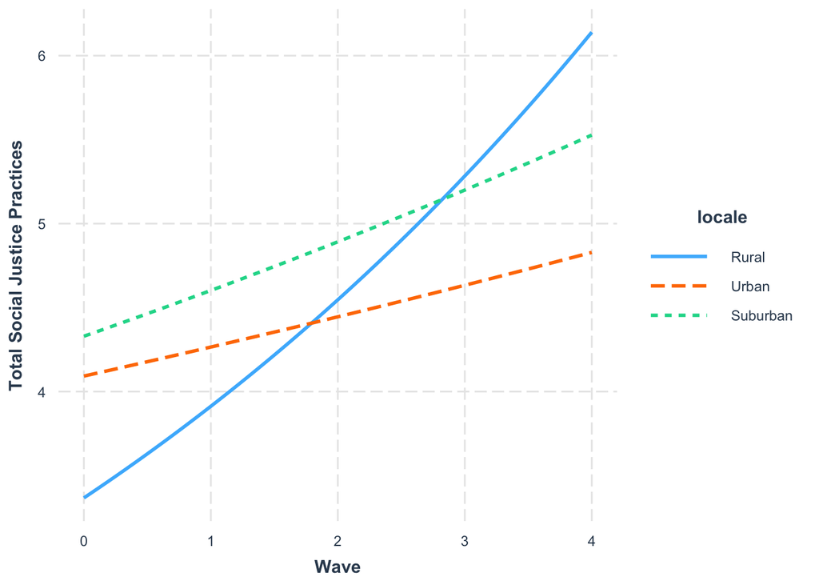

```r
interact_plot(model=GLMMfix_wave_inter, pred = wave, modx = locale) +
  labs(x = "Wave", y = "Total Social Justice Practices")
```

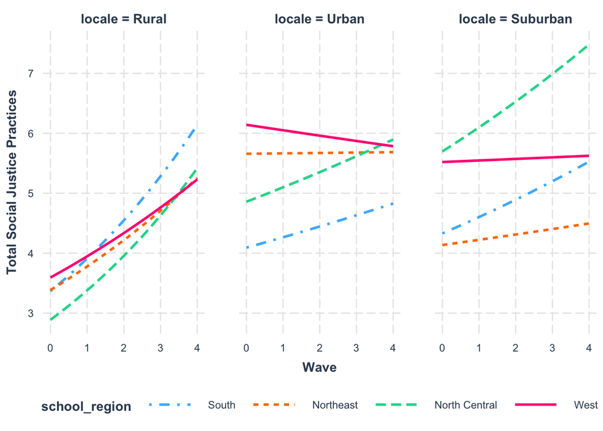

```r
# This is a little confusing and might be wrong but seems to indicate the Urban schools were consistently higher while Rural schools have been climbing steeply

interact_plot(model=GLMMfix_wave_inter, pred = wave, modx = school_region, mod2 = locale) +
  labs(x = "Wave", y = "Total Social Justice Practices")
```

```r
# Additionally, that growth seems to be dominated by the North central "Midwest-ish" and the south.
```

This final graph is perhaps the most interesting one that we have.